# HW2 Alvaro Martin

### MODEL SELECTION:

Are all the variables needed to predict? Objective: To identify the subset of the p variables that is really associated to the response

```r
model = Health ~ I(Age^2) + log(Cholesterol+20) + I(MaxHR^2) +RestingBP+Oldpeak

linFit <- lm(model, data=training)

ols_step_all_possible(linFit)
```

|  | mindex | n | predictors | rsquare | adjr | predrsq | cp | aic | sbic | sbc | msep | fpe | apc | hsp |
| --- | --- | --- | --- | --- | --- | --- | --- | --- | --- | --- | --- | --- | --- | --- |
| 2 | 1 | 1 | log(Cholesterol + 20) | 0.38408816 | 0.38319294 | 0.38034151 | 1499.852890 | 3907.425 | 1945.615 | 3921.035 | 11567.512 | 16.813103 | 0.6194927 | 0.024402489 |
| 1 | 2 | 1 | I(Age^2) | 0.27162991 | 0.27057123 | 0.26518284 | 1898.963898 | 4023.141 | 2060.999 | 4036.751 | 13679.604 | 19.882978 | 0.7326048 | 0.028858097 |
| 3 | 3 | 1 | I(MaxHR^2) | 0.21122619 | 0.21007972 | 0.20309712 | 2113.334919 | 4078.114 | 2115.829 | 4091.724 | 14814.053 | 21.531873 | 0.7933597 | 0.031251298 |
| 4 | 4 | 1 | RestingBP | 0.07487967 | 0.07353502 | 0.06968777 | 2597.224689 | 4188.130 | 2225.588 | 4201.740 | 17374.793 | 25.253847 | 0.9304989 | 0.036653361 |
| 5 | 5 | 1 | Oldpeak | 0.01958192 | 0.01815689 | 0.01398076 | 2793.474770 | 4228.188 | 2265.561 | 4241.799 | 18413.347 | 26.763360 | 0.9861182 | 0.038844264 |
| 6 | 6 | 2 | I(Age^2) log(Cholesterol + 20) | 0.60671951 | 0.60557459 | 0.60179857 | 711.740820 | 3599.904 | 1638.223 | 3618.051 | 7397.014 | 10.766897 | 0.3967153 | 0.015627241 |
| 10 | 7 | 2 | log(Cholesterol + 20) I(MaxHR^2) | 0.58407399 | 0.58286315 | 0.57770758 | 792.109096 | 3638.533 | 1676.635 | 3656.680 | 7822.942 | 11.386867 | 0.4195585 | 0.016527074 |
| 7 | 8 | 2 | I(Age^2) I(MaxHR^2) | 0.43979530 | 0.43816443 | 0.43259689 | 1304.149899 | 3844.011 | 1881.106 | 3862.158 | 10536.607 | 15.336806 | 0.5650973 | 0.022260076 |
| 11 | 9 | 2 | log(Cholesterol + 20) RestingBP | 0.42329449 | 0.42161558 | 0.41820872 | 1362.710802 | 3864.042 | 1901.051 | 3882.189 | 10846.963 | 15.788551 | 0.5817422 | 0.022915746 |
| 12 | 10 | 2 | log(Cholesterol + 20) Oldpeak | 0.39625160 | 0.39449396 | 0.39104480 | 1458.685217 | 3895.662 | 1932.539 | 3913.808 | 11355.599 | 16.528908 | 0.6090213 | 0.023990312 |

[output cut: 21 more lines]

```r
# All possible subset regressions: the number is exponential with p
# We have 2^p combinations of the predictors.
```

We have to see which is the combination with better results (in terms of R^2, AIC, BIC…) The 26th (I(Age^2) log(Cholesterol + 20) I(MaxHR^2) RestingBP) and the 31st (I(Age^2) log(Cholesterol + 20) I(MaxHR^2) RestingBP Oldpeak) combinations are the ones with better results. From this we can conclude that maybe Oldpeak is not very important to make our predictions,because the results doens’t change much when this variable is incorporated to the model, while including or not the rest of the variables affects much more the performance.

```r
ols_step_best_subset(linFit)
```

|  | mindex | n | predictors | rsquare | adjr | predrsq | cp | aic | sbic | sbc | msep | fpe | apc | hsp |
| --- | --- | --- | --- | --- | --- | --- | --- | --- | --- | --- | --- | --- | --- | --- |
| 2 | 1 | 1 | log(Cholesterol + 20) | 0.3840882 | 0.3831929 | 0.3803415 | 1499.852890 | 3907.425 | 1945.615 | 3921.035 | 11567.512 | 16.813103 | 0.6194927 | 0.024402489 |
| 6 | 2 | 2 | I(Age^2) log(Cholesterol + 20) | 0.6067195 | 0.6055746 | 0.6017986 | 711.740820 | 3599.904 | 1638.223 | 3618.051 | 7397.014 | 10.766897 | 0.3967153 | 0.015627241 |
| 16 | 3 | 3 | I(Age^2) log(Cholesterol + 20) I(MaxHR^2) | 0.7692027 | 0.7681934 | 0.7649713 | 137.092814 | 3234.145 | 1274.700 | 3256.829 | 4347.287 | 6.336913 | 0.2334888 | 0.009197648 |
| 26 | 4 | 4 | I(Age^2) log(Cholesterol + 20) I(MaxHR^2) RestingBP | 0.8070142 | 0.8058873 | 0.8025061 | 4.900803 | 3112.688 | 1154.627 | 3139.908 | 3640.385 | 5.314118 | 0.1958031 | 0.007713285 |
| 31 | 5 | 5 | I(Age^2) log(Cholesterol + 20) I(MaxHR^2) RestingBP Oldpeak | 0.8072680 | 0.8058592 | 0.8023180 | 6.000000 | 3113.780 | 1155.750 | 3145.537 | 3640.920 | 5.322535 | 0.1961132 | 0.007725697 |

```r
# The best subset regression for each p.
```

We can see again that the combination of I(Age^2) log(Cholesterol + 20) I(MaxHR^2) RestingBP is the one with better results (lowest Akaike information criterion (AIC), lowest Bayesian information criterio (BIC) and the highest Rsquared alogn with the model that includes variable Oldpeak). Again, we can conclude that we shouldn’t consider variable Oldpeak in our model, because it makes it more complex but doesn’t improve the performance.

Visualizating the results we can see it clearer:

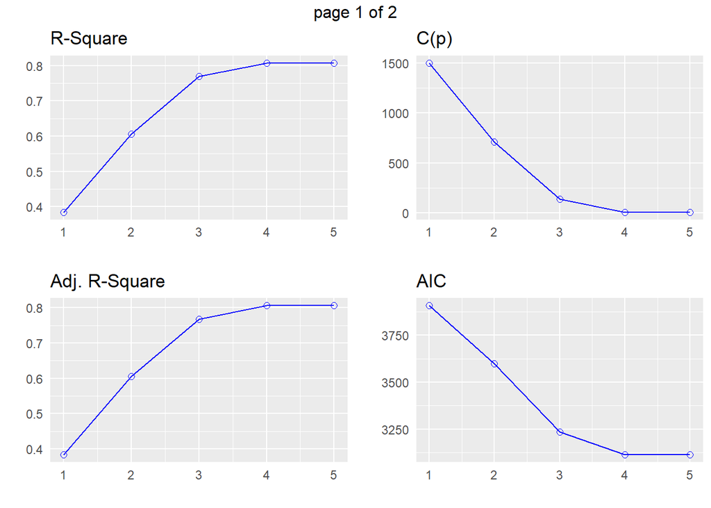

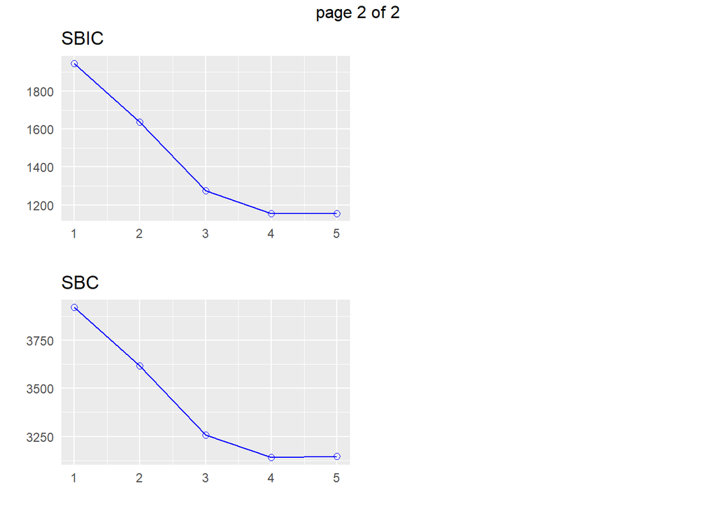

```r
plot(ols_step_best_subset(linFit))
```

```r
# We can observe that the performance of our model improves everytime we incorporate a new variable until 4, but then when we include the fifth variable (Oldpeak), the model does not improve the results.
```

Backward elimination and stepwise selection

```r
# The backward elimination technique is used in machine learning to find the best subset of features from a given set of features.

# It works by iteratively removing features that are not predictive of the target variable or have the least predictive power
ols_step_backward_aic(linFit) # backward AIC
```

```
##
##
##                       Backward Elimination Summary
## -----------------------------------------------------------------------
## Variable        AIC         RSS        Sum Sq       R-Sq      Adj. R-Sq
## -----------------------------------------------------------------------
## Full Model    3113.780    3609.229    15117.449    0.80727      0.80586
## Oldpeak       3112.688    3613.983    15112.696    0.80701      0.80589
## -----------------------------------------------------------------------
```

```r
# This also confirms what we have seen before.
ols_step_both_aic(linFit) # stepwise AIC
```

```
##
##
##                                         Stepwise Summary
## -----------------------------------------------------------------------------------------------
## Variable                  Method       AIC          RSS        Sum Sq       R-Sq      Adj. R-Sq
## -----------------------------------------------------------------------------------------------
## log(Cholesterol + 20)    addition    3907.425    11533.983     7192.696    0.38409      0.38319
## I(Age^2)                 addition    3599.904     7364.837    11361.841    0.60672      0.60557
## I(MaxHR^2)               addition    3234.145     4322.067    14404.612    0.76920      0.76819
## RestingBP                addition    3112.688     3613.983    15112.696    0.80701      0.80589
## -----------------------------------------------------------------------------------------------
```

With all these results, we can come to the conclusion that a good model for use would be:

```r
linFit <- lm(Health ~ I(Age^2) + log(Cholesterol+20) + I(MaxHR^2) +RestingBP, data=training)
summary(linFit)
```

```
##
## Call:
## lm(formula = Health ~ I(Age^2) + log(Cholesterol + 20) + I(MaxHR^2) +
##     RestingBP, data = training)
##
## Residuals:
##      Min       1Q   Median       3Q      Max
## -10.7598  -1.4965   0.1769   1.7435   6.7490
##
## Coefficients:
##                        Estimate Std. Error t value Pr(>|t|)
## (Intercept)           192.75736    5.94514   32.42   <2e-16 ***
## I(Age^2)                1.68607    0.06715   25.11   <2e-16 ***
## log(Cholesterol + 20) -64.52269    1.98331  -32.53   <2e-16 ***
## I(MaxHR^2)              1.68630    0.06903   24.43   <2e-16 ***
## RestingBP              -1.01701    0.08779  -11.59   <2e-16 ***
## ---
## Signif. codes:  0 '***' 0.001 '**' 0.01 '*' 0.05 '.' 0.1 ' ' 1
##
## Residual standard error: 2.297 on 685 degrees of freedom
## Multiple R-squared:  0.807,  Adjusted R-squared:  0.8059
## F-statistic: 716.1 on 4 and 685 DF,  p-value: < 2.2e-16
```

```r
predictions <- predict(linFit, newdata=testing)
cor(testing$Health, predictions)^2
```

```
## [1] 0.7801806
```

```r
# This model seems good and give us nice results in the test set as well
```

**Benchmark model**

```r
mean(training$Health)
```

```
## [1] 2.93265
```

```r
# This is equivalent to
benchFit <- lm(Health ~ 1, data=training)
benchFit$coefficients
```

```
## (Intercept)
##     2.93265
```

```r
predictions <- predict(benchFit, newdata=testing)
RMSE <- sqrt(mean((predictions - testing$Health)^2))
# Well, the benchmark model is quite good (taking into account that it is very simple).
```

[output not shown]

### Statistical Learning tools

```r
ctrl <- trainControl(method = "repeatedcv",
                     number = 5, repeats=1)

# We previously had the doubt whether to include Oldpeak in the model or not, so we are going to create to models and compare the results:
ModelS = Health ~ I(Age^2) + log(Cholesterol+20) + I(MaxHR^2) +RestingBP

ModelF = Health ~ I(Age^2) + log(Cholesterol+20) + I(MaxHR^2) +RestingBP+Oldpeak

test_results <- data.frame(Health = testing$Health)
```

### Visualization of the Linear regression

```r
lm_tune <- train(ModelS, data = training,
                 method = "lm",
                 preProc=c('scale', 'center'),
                 trControl = ctrl)
lm_tune
```

```
## Linear Regression
##
## 690 samples
##   4 predictor
##
## Pre-processing: scaled (4), centered (4)
## Resampling: Cross-Validated (5 fold, repeated 1 times)
## Summary of sample sizes: 552, 553, 552, 551, 552
## Resampling results:
##
##   RMSE      Rsquared   MAE
##   2.317997  0.8034514  1.867262
##
## Tuning parameter 'intercept' was held constant at a value of TRUE
```

```r
# Predict
test_results$lm <- predict(lm_tune, testing)
postResample(pred = test_results$lm,  obs = test_results$Health)
```

```
##      RMSE  Rsquared       MAE
## 2.2120805 0.7801806 1.8335637
```

Visualization

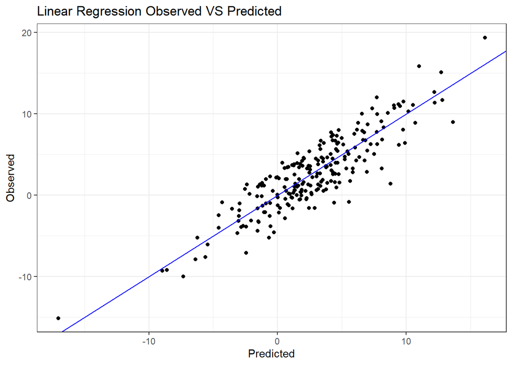

```r
qplot(test_results$lm, test_results$Health) +
  labs(title="Linear Regression Observed VS Predicted", x="Predicted", y="Observed")  +
  geom_abline(intercept = 0, slope = 1, colour = "blue") +
  theme_bw()
```

In the grpahs we can see that the results are very good. As the axis of the grpahs are the predicted value and the actual value, the point in the diagonal are perfect predictions. As the majority of our points are around the diagonal, we can conclude that the model is good.

### Overfitted linear regression

Train

```r
alm_tune <- train(ModelF, data = training,
                  method = "lm",
                  preProc=c('scale', 'center'),
                  trControl = ctrl)
```

Predict

```r
test_results$alm <- predict(alm_tune, testing)
postResample(pred = test_results$alm,  obs = test_results$Health)
```

```
##      RMSE  Rsquared       MAE
## 2.2149267 0.7797273 1.8309448
```

Visualization

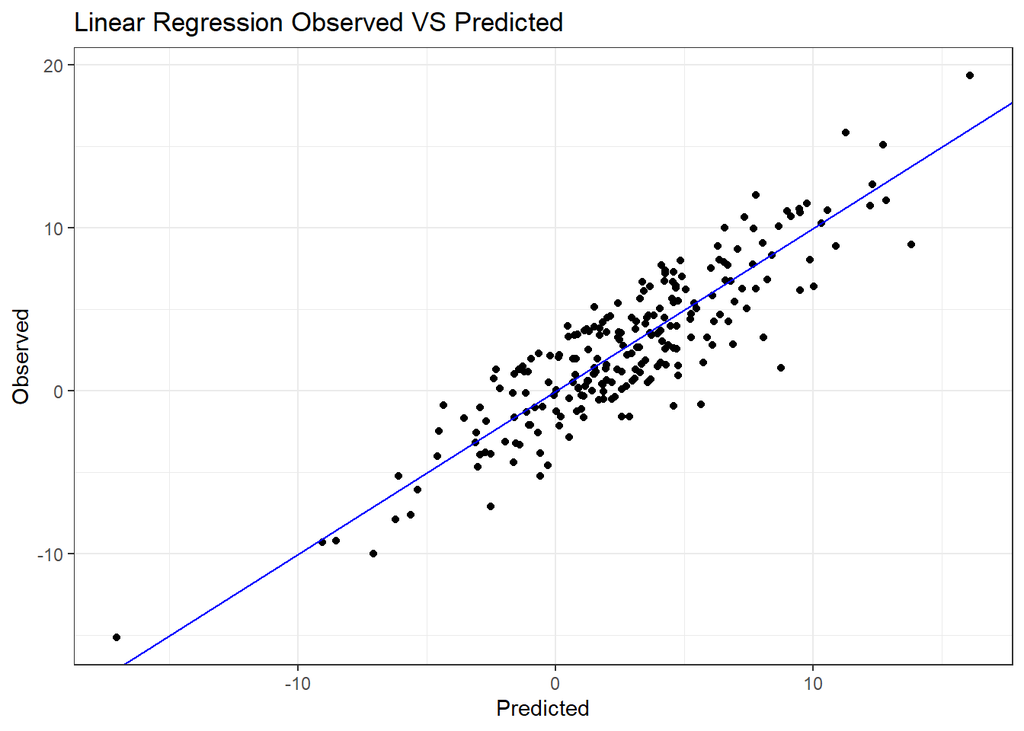

```r
qplot(test_results$alm, test_results$Health) +
  labs(title="Linear Regression Observed VS Predicted", x="Predicted", y="Observed") +
  geom_abline(intercept = 0, slope = 1, colour = "blue") +
  theme_bw()
```

In this case our results have not improve after training the model (they are almost the same as before), and does not seem that we have an overfitted model. However, although it is positive to train your model in order to achieve the best possible performance, we have to be careful about overfitting. It may be possible that our model has less bias, but increases variance a lot. We always have to be careful and concern about it.

## Backward regression

```r
back_tune  <- train(ModelF, data = training,
                  method = "leapBackward",
                  tuneGrid = expand.grid(nvmax = 2:5),
                  trControl = ctrl)

back_tune
```

```
## Linear Regression with Backwards Selection
##
## 690 samples
##   5 predictor
##
## No pre-processing
## Resampling: Cross-Validated (5 fold, repeated 1 times)
## Summary of sample sizes: 551, 551, 552, 553, 553
## Resampling results across tuning parameters:
##
##   nvmax  RMSE      Rsquared   MAE
##   2      3.431453  0.5726075  2.602437
##   3      2.516517  0.7663596  1.998347
##   4      2.307856  0.8040493  1.867618
##   5      2.309300  0.8038322  1.872208
##
## RMSE was used to select the optimal model using the smallest value.
## The final value used for the model was nvmax = 4.
```

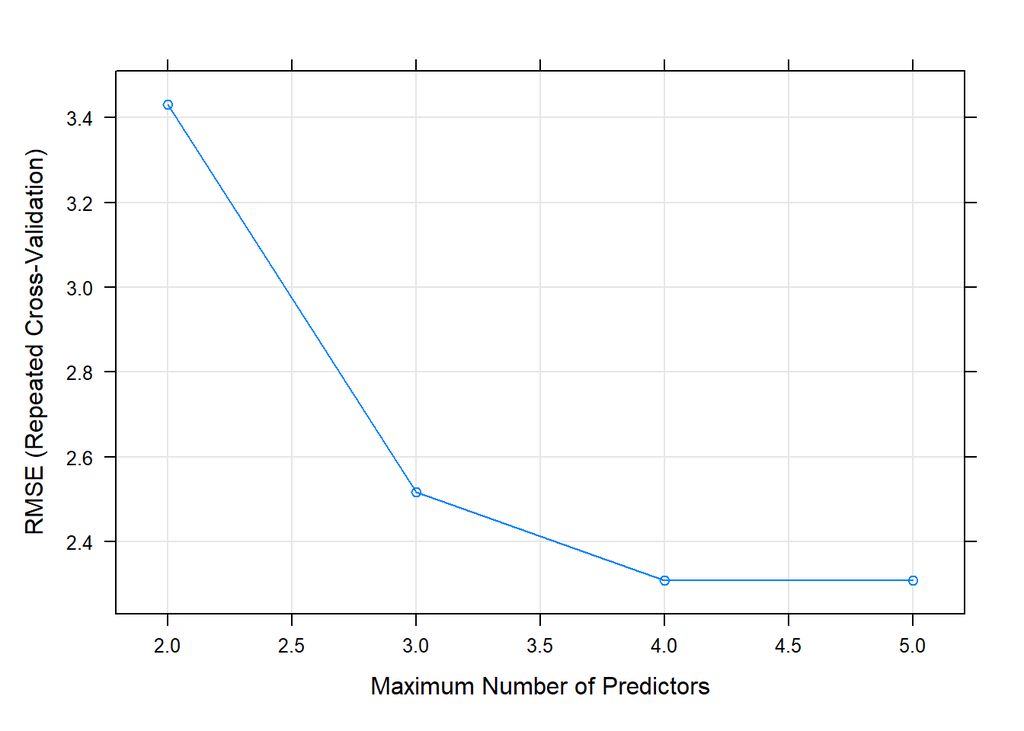

```r
plot(back_tune)
```

Remember that the lower RMSE the better. So in this case using 4 variables to predict would be the best option. Inlsuding a fifth variable doesn’t improve the performance of the model.

Which variables are selected?

```r
coef(back_tune$finalModel, back_tune$bestTune$nvmax)
```

```
##           (Intercept)              I(Age^2) log(Cholesterol + 20)
##            192.757364              1.686074            -64.522692
##            I(MaxHR^2)             RestingBP
##              1.686296             -1.017007
```

We always arrive to the same conclusion, we should leave Oldpeak variable out of our model.

Predict

```r
test_results$frw <- predict(back_tune, testing)
postResample(pred = test_results$frw,  obs = test_results$Health)
```

```
##      RMSE  Rsquared       MAE
## 2.2120805 0.7801806 1.8335637
```

Visualization

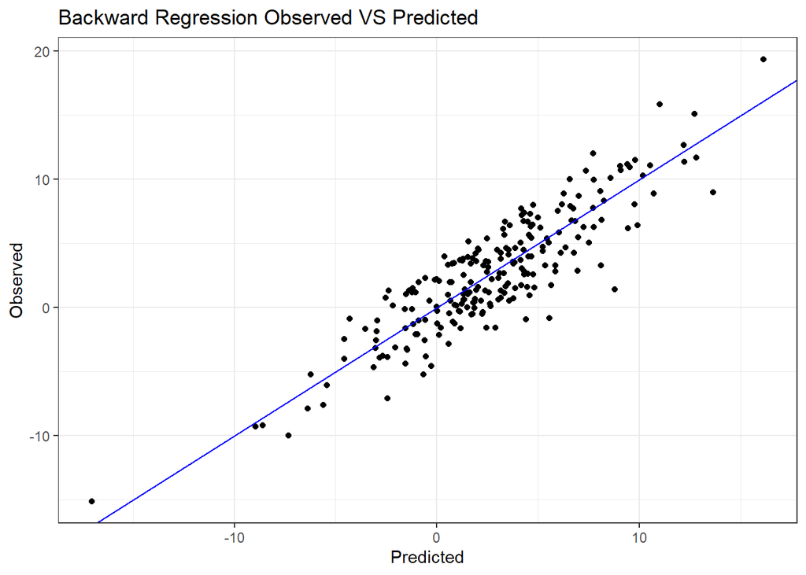

```r
qplot(test_results$frw, test_results$Health) +
  labs(title="Backward Regression Observed VS Predicted", x="Predicted", y="Observed") +
  geom_abline(intercept = 0, slope = 1, colour = "blue") +
  theme_bw()
```

## KNN

```r
modelLookup('kknn')
```

|  | model | parameter | label | forReg | forClass | probModel |
| --- | --- | --- | --- | --- | --- | --- |
| 1 | kknn | kmax | Max. #Neighbors | TRUE | TRUE | TRUE |
| 2 | kknn | distance | Distance | TRUE | TRUE | TRUE |
| 3 | kknn | kernel | Kernel | TRUE | TRUE | TRUE |

```r
# 3 hyper-parameters: kmax, distance, kernel
# kmax: number of neighbors considered
# distance: parameter of Minkowski distance (p in Lp)
# kernel: "rectangular" (standard unweighted knn), "triangular", "epanechnikov" (or beta(2,2)), "biweight" (or beta(3,3)), "tri- weight" (or beta(4,4)), "cos", "inv", "gaussian", "rank" and "optimal".
```

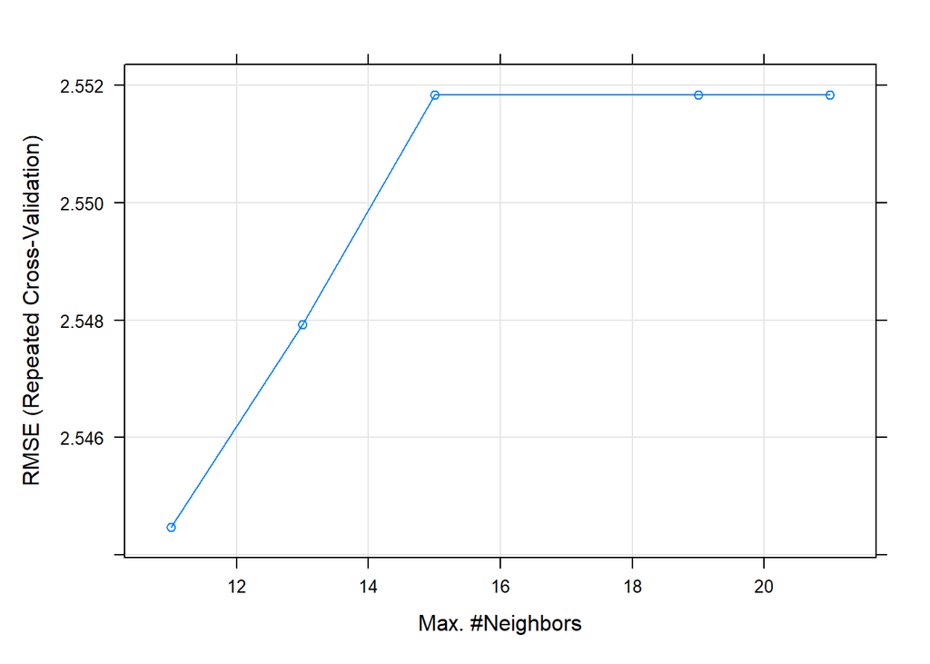

```r
knn_tune <- train(ModelS,
                  data = training,
                  method = "kknn",
                  preProc=c('scale','center'),
                  tuneGrid = data.frame(kmax=c(11,13,15,19,21),distance=2,kernel='optimal'),
                  trControl = ctrl)
plot(knn_tune)
```

```r
test_results$knn <- predict(knn_tune, testing)

postResample(pred = test_results$knn,  obs = test_results$Health)
```

```
##     RMSE Rsquared      MAE
## 2.403068 0.742986 1.973718
```

In general, we can see that we obtain similar results with all the models. This resuls are also good.

## Random Forest

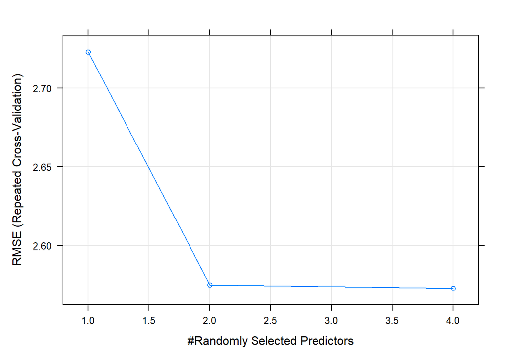

```r
rf_tune <- train(ModelS,
                 data = training,
                 method = "rf",
                 preProc=c('scale','center'),
                 trControl = ctrl,
                 ntree = 100,
                 tuneGrid = data.frame(mtry=c(1,2,2,4)),
                 importance = TRUE)

plot(rf_tune)
```

```r
test_results$rf <- predict(rf_tune, testing)

postResample(pred = test_results$rf,  obs = test_results$Health)
```

```
##      RMSE  Rsquared       MAE
## 2.3225074 0.7573141 1.9169274
```

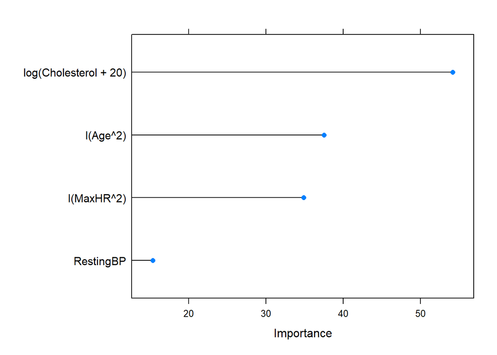

```r
plot(varImp(rf_tune, scale = F), scales = list(y = list(cex = .95)))
```

As we know the formula that we used to create the variable to predict, we can see that these results are very accurate. In the formula we made Cholesterol the most important variable to predict, and RestingBP the one with less influence, and this is exactly what we can see in this graph.

**Final conclusion**

I tried to make all the part of regression as if I didn’t know what was the formula of the dependent variable, and in the end I think I arrive to a model very similar to the hypothethical best model.

My final model was: Health ~ I(Age^2) + log(Cholesterol+20) + I(MaxHR^2) +RestingBP

And the best possible model (knowing the formula) would be: Health ~ I(-RestingBP) + I(3*Cholesterol) + I((MaxHR-Age)^2)

So we succesfully found which were the variables involved (we left Oldpeak out), and also find out which were the most important variables. We arrived to a model very similar to the best possible one and that could predict very good the variable of interest.

# Sources:

I took the dataset from an exam of last year of introduction to data science.

https://www.statmethods.net/

https://r-graph-gallery.com/

https://r-coder.com/

http://www.sthda.com/english/articles/36-classification-methods-essentials/149-penalized-logistic-regression-essentials-in-r-ridge-lasso-and-elastic-net/

https://www.rdocumentation.org/

My notes of classification from last year.

The presentations and examples available in aulaglobal.

https://www.investopedia.com/terms/s/stepwise-regression.asp#:~:text=Stepwise%20regression%20is%20the%20step,statistical%20significance%20after%20each%20iteration.

https://www.cdc.gov/bloodpressure/about.htm#:~:text=%2F80%20mmHg.%E2%80%9D-,What%20are%20normal%20blood%20pressure%20numbers%3F,less%20than%20120%2F80%20mmHg.&text=No%20matter%20your%20age%2C%20you,pressure%20in%20a%20healthy%20range.